# Heterogeneous Regression Ensemble to Determine the Effects of Alcohol on Student GPA

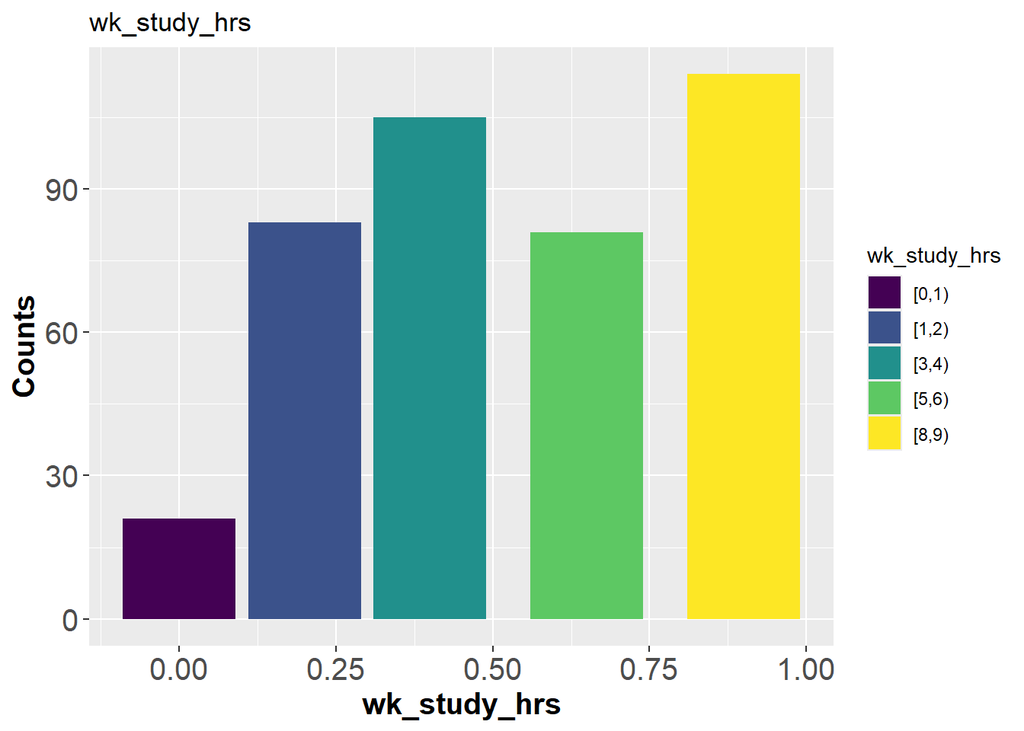

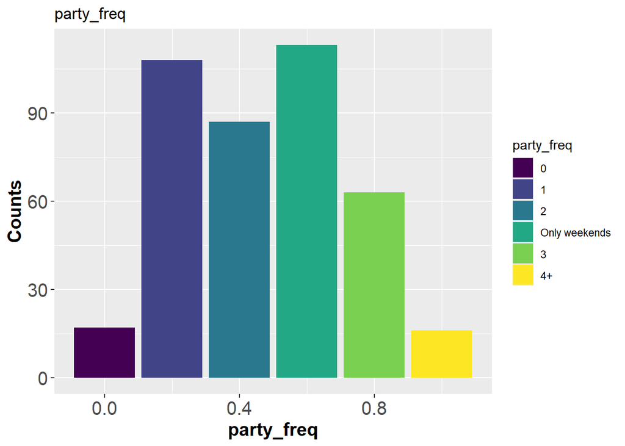

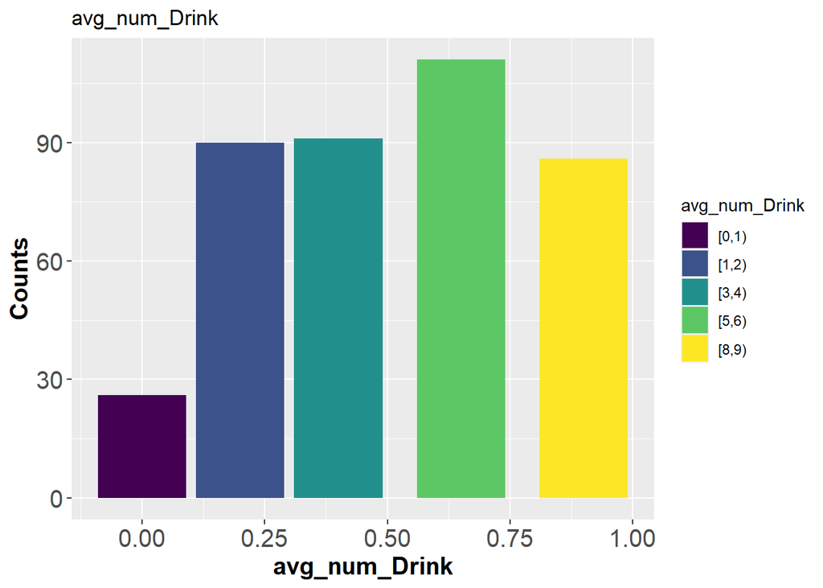

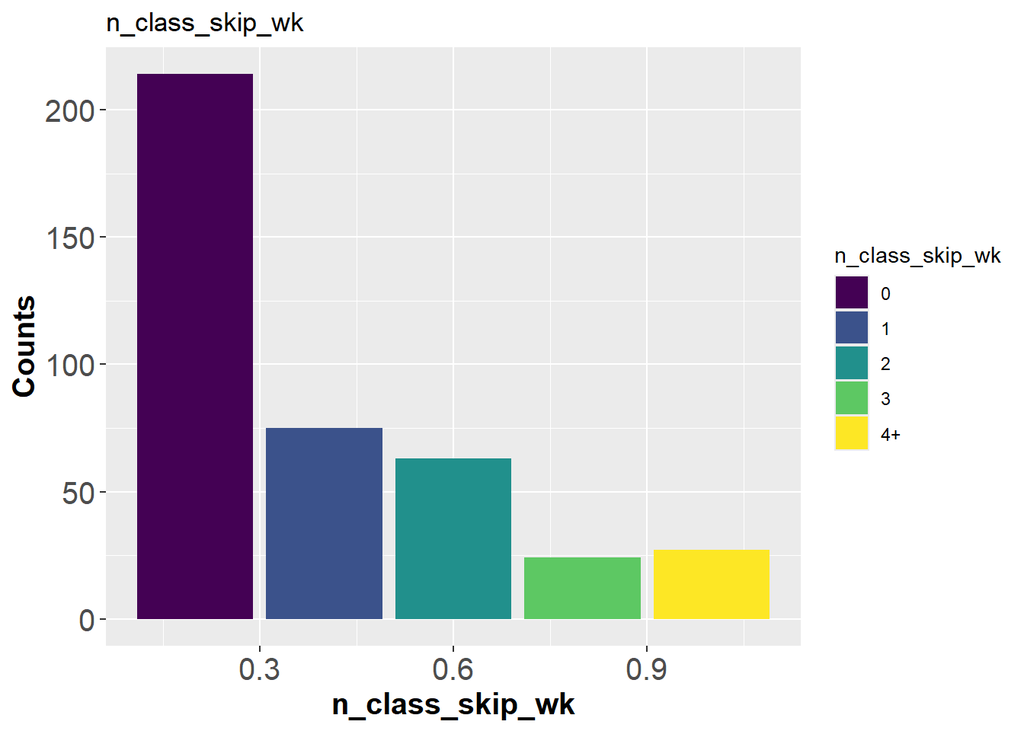

[4 more figures not shown]

**Class-Imbalance note** : methods like “smote” work for classification with probability not regression for continuous variables, instead using `preProcess transformation th center and scale can help, but linear regression should handle the imbalance somewhat natural, but it may underestimate the impact of a feature and have lower coefficients in SVR or Lasso, but Random Forest handles imbalanced data well without transformations.

## 5. Missing Values : Re-Evaluation and Imputation

### 1. Review Original Findings:

Pairwise Prevelence of NA Incomplete Observations

| Number_of_NA | Obs_Count | Prop_NA_obs | Prop_All_obs |
| --- | --- | --- | --- |
| 1 | 32 | 0.123 | 0.079 |
| 2 | 51 | 0.196 | 0.126 |
| 3 | 14 | 0.054 | 0.034 |
| 4 | 8 | 0.031 | 0.020 |
| 5 | 4 | 0.015 | 0.010 |
| 16 | 2 | 0.008 | 0.005 |

Number of `NA` Values and unique levels present in each Feature

|  | numNA | numLvl |
| --- | --- | --- |
| Target_gpa.23 | 86 | 46 |
| grade_lvl_2023 | 73 | 6 |
| mon_allowance | 31 | 6 |
| isPrivateAcc | 23 | 3 |
| hasScholarship | 8 | 3 |
| matric_GPA | 7 | 44 |
| faculty | 7 | 9 |
| p_Approve_Alc | 4 | 3 |
| wk_study_hrs | 3 | 6 |
| n_class_skip_wk | 3 | 6 |
| num_Fail.mod | 3 | 6 |
| inRelationship | 3 | 3 |
| p_Relationship | 3 | 5 |
| isFemale | 2 | 3 |
| party_freq | 2 | 7 |
| avg_num_Drink | 2 | 6 |

### 2. `Target_gpa.23` Imputations

#### 1. Incoming Freshman : Previously assigned for `grade_lvl_2023`

Assume all observations that have `grade_lvl_2023` and `Target_gpa.23` as `NA` to be “incoming freshmen” meaning the observation’s `matric_GPA` is the target value and should be directly substituted.

Target GPA imputed as Matric for all assumed ‘incoming freshmen’

|  | Target_gpa.23 | matric_GPA | isFemale | grade_lvl_2023 | faculty | isPrivateAcc | mon_allowance | hasScholarship | wk_study_hrs | party_freq | avg_num_Drink | n_class_skip_wk | num_Fail.mod | inRelationship | p_Approve_Alc | p_Relationship |
| --- | --- | --- | --- | --- | --- | --- | --- | --- | --- | --- | --- | --- | --- | --- | --- | --- |
| 6 | 83.00 | 83.00 | 0 | 0 | 0.092 | 1 | 0.65005 | 0 | 0.90 | 1.0 | 0.40 | 0.8 | 0.4 | 1 | 1 | 0.9 |
| 9 | 89.00 | 89.00 | 0 | 0 | 0.092 | NA | 0.55005 | 0 | 0.90 | 0.6 | 0.40 | 0.2 | NA | 0 | 1 | 0.9 |
| 10 | 83.00 | 83.00 | 0 | 0 | 0.024 | NA | 0.65005 | 0 | 0.40 | 0.8 | 0.65 | 1.0 | 0.2 | 0 | 1 | 0.6 |
| 11 | 75.00 | 75.00 | 1 | 0 | 0.054 | NA | 0.45005 | 0 | 0.65 | 0.4 | 0.65 | 0.2 | 0.2 | 0 | 1 | 0.6 |
| 15 | 78.00 | 78.00 | 0 | 0 | 0.024 | NA | 0.00000 | NA | 0.40 | 0.4 | 0.65 | 0.2 | 0.2 | 0 | 1 | 0.9 |
| 17 | 86.00 | 86.00 | 1 | 0 | 0.092 | 1 | 0.00000 | 0 | 0.40 | 0.2 | 0.40 | 0.2 | 0.2 | 0 | 1 | 0.3 |
| 19 | 83.00 | 83.00 | 1 | 0 | 0.139 | 1 | 0.00000 | 0 | 0.90 | 0.6 | 0.20 | 0.2 | 0.2 | 1 | 1 | 0.9 |
| 33 | 84.00 | 84.00 | 0 | 0 | 0.522 | 1 | 0.55005 | 0 | 0.90 | 0.6 | 0.65 | 0.2 | 0.2 | 0 | 1 | 0.6 |
| 44 | 83.00 | 83.00 | 1 | 0 | 0.522 | 1 | 0.55005 | 0 | 0.20 | 0.6 | 0.20 | 0.2 | 0.2 | 0 | 1 | 0.6 |
| 45 | 80.00 | 80.00 | 1 | 0 | 0.522 | 1 | 0.45005 | 0 | 0.20 | 0.6 | 0.20 | 0.2 | 0.2 | 1 | 1 | 0.9 |
| 46 | 80.00 | 80.00 | 1 | 0 | 0.116 | 1 | 0.55005 | 0 | 0.40 | 0.4 | 0.40 | 0.6 | 0.2 | 1 | 1 | 0.9 |
| 52 | 70.00 | 70.00 | 0 | 0 | 0.522 | 1 | 0.75005 | 0 | 0.40 | 0.2 | 0.40 | 0.2 | 0.2 | 0 | 1 | 0.6 |
| 69 | 73.00 | 73.00 | 1 | 0 | 0.116 | 1 | 0.45005 | 1 | 0.40 | 0.4 | 0.20 | 0.2 | 0.2 | 0 | 1 | 0.9 |
| 78 | 87.00 | 87.00 | 1 | 0 | 0.024 | NA | 0.00000 | NA | 0.90 | 0.6 | 0.20 | 0.2 | 0.2 | 0 | 1 | 0.9 |
| 98 | 68.00 | 68.00 | 0 | 0 | 0.116 | 1 | 0.45005 | 0 | 0.40 | 0.2 | 0.90 | 0.2 | 0.2 | 0 | 1 | 0.9 |
| 105 | 66.00 | 66.00 | 0 | 0 | 0.522 | 1 | 0.45005 | 0 | 0.90 | 0.8 | 0.90 | 0.2 | 0.2 | 1 | 1 | 0.9 |
| 116 | 84.00 | 84.00 | 1 | 0 | 0.522 | NA | 0.00000 | NA | 0.00 | 0.8 | 0.65 | 0.2 | 0.2 | 0 | 1 | 0.6 |
| 130 | 76.00 | 76.00 | 0 | 0 | 0.522 | 1 | 0.55005 | 0 | 0.65 | 0.8 | 0.90 | 0.6 | 0.2 | 0 | 1 | 0.9 |
| 138 | 65.00 | 65.00 | 0 | 0 | 0.024 | 1 | 0.65005 | 1 | 0.40 | 0.4 | 0.90 | 0.4 | 0.2 | 0 | 1 | 0.9 |
| 154 | 85.00 | 85.00 | 1 | 0 | 0.116 | NA | 0.00000 | 0 | 0.20 | 0.2 | 0.40 | 0.2 | 0.2 | 0 | 0 | 0.6 |
| 164 | 69.00 | 69.00 | 1 | 0 | 0.522 | NA | 0.00000 | 0 | 0.40 | 0.2 | 0.20 | 0.2 | 0.2 | 1 | 1 | 0.9 |
| 167 | 74.00 | 74.00 | 1 | 0 | 0.024 | 1 | 0.65005 | 0 | 0.90 | 0.4 | 0.20 | 0.2 | 0.2 | 0 | 1 | 0.9 |
| 169 | 74.00 | 74.00 | 0 | 0 | 0.522 | 1 | 0.45005 | 0 | 0.40 | 0.2 | 0.20 | 0.2 | 0.2 | 0 | 1 | 0.9 |
| 172 | 73.00 | 73.00 | 1 | 0 | 0.522 | NA | 0.45005 | 0 | 0.20 | 0.2 | 0.65 | 0.2 | 0.2 | 0 | 1 | 0.9 |
| 173 | 78.00 | 78.00 | 0 | 0 | 0.522 | 1 | 0.55005 | 0 | 0.65 | 0.2 | 0.65 | 0.8 | 0.2 | 0 | 1 | 0.9 |
| 181 | 79.00 | 79.00 | 0 | 0 | 0.092 | NA | 0.65005 | NA | 0.40 | 0.0 | 0.00 | 0.2 | 0.2 | 0 | 1 | 0.6 |
| 192 | 86.00 | 86.00 | 0 | 0 | 0.092 | 1 | 0.45005 | 0 | 0.90 | 0.0 | 0.65 | 0.4 | 0.2 | 1 | 1 | 0.9 |
| 228 | 94.00 | 94.00 | 1 | 0 | 0.092 | 1 | 0.55005 | 0 | 0.40 | 0.4 | 0.20 | 0.2 | 0.2 | 0 | 1 | 0.9 |
| 254 | 83.00 | 83.00 | 0 | 0 | 0.522 | 1 | 0.85005 | 0 | 0.40 | 0.6 | 0.20 | 0.2 | 0.2 | 0 | 1 | 0.9 |
| 255 | 34.00 | 34.00 | 0 | 0 | 0.522 | 1 | 0.45005 | 0 | 0.65 | 0.6 | 0.65 | 0.4 | 0.2 | 0 | 1 | 0.9 |
| 258 | 74.00 | 74.00 | 0 | 0 | 0.522 | 1 | 0.45005 | 0 | 0.00 | 0.4 | 0.65 | 0.8 | 0.2 | 0 | 1 | 0.9 |
| 259 | 79.00 | 79.00 | 0 | 0 | 0.522 | 1 | 0.45005 | 1 | 0.90 | 0.8 | 0.90 | 0.2 | 0.2 | 0 | 1 | 0.9 |
| 262 | 71.00 | 71.00 | 0 | 0 | 0.522 | 1 | 0.45005 | 1 | 0.40 | 0.4 | 0.90 | 0.4 | 0.2 | 1 | 1 | 0.9 |
| 265 | 73.00 | 73.00 | 0 | 0 | 0.024 | 1 | 0.45005 | 0 | 0.40 | 0.6 | 0.90 | 0.2 | 0.2 | 0 | 1 | 0.9 |
| 266 | 83.00 | 83.00 | 0 | 0 | 0.092 | 1 | 0.45005 | 0 | 0.90 | 0.2 | 0.65 | 0.4 | 0.2 | 0 | 1 | 0.9 |
| 268 | NA | NA | 0 | 0 | 0.116 | 1 | 0.85005 | 0 | 0.00 | 0.6 | 0.65 | 0.6 | 0.2 | 1 | 1 | 0.9 |
| 271 | 85.00 | 85.00 | 0 | 0 | 0.092 | 1 | 0.45005 | 0 | 0.20 | 0.4 | 0.40 | 0.4 | 0.2 | 1 | 0 | 0.3 |
| 276 | 80.00 | 80.00 | 0 | 0 | 0.092 | 1 | 0.45005 | 1 | 0.90 | 0.6 | 0.40 | 0.2 | 0.2 | 0 | 1 | 0.9 |
| 277 | 74.00 | 74.00 | 0 | 0 | 0.522 | 1 | 0.45005 | 1 | 0.20 | 0.6 | 0.90 | 0.6 | 0.2 | 1 | 1 | 0.6 |
| 282 | 81.00 | 81.00 | 0 | 0 | 0.092 | 1 | 0.45005 | 0 | 0.65 | 0.2 | 0.40 | 0.2 | 0.2 | 0 | 1 | 0.9 |
| 283 | 65.00 | 65.00 | 1 | 0 | 0.522 | 1 | 0.45005 | 0 | 0.65 | 0.6 | 0.65 | 0.2 | 0.2 | 1 | 1 | 0.9 |
| 286 | 75.00 | 75.00 | 0 | 0 | 0.522 | 1 | 0.55005 | 0 | 0.40 | 0.4 | 0.20 | 0.2 | 0.2 | 0 | 1 | 0.6 |
| 289 | 80.00 | 80.00 | 0 | 0 | 0.116 | 1 | 0.85005 | 0 | 0.40 | 0.2 | 0.90 | 0.2 | 0.2 | 0 | 1 | 0.6 |
| 297 | 65.00 | 65.00 | 0 | 0 | 0.522 | 1 | 0.00000 | 0 | 0.20 | 0.8 | 0.65 | 0.4 | 0.2 | 0 | 1 | 0.9 |
| 299 | 83.00 | 83.00 | 1 | 0 | 0.024 | 1 | 0.45005 | 0 | 0.90 | 0.2 | 0.40 | 0.2 | 0.2 | 0 | 1 | 0.9 |
| 301 | 76.00 | 76.00 | 0 | 0 | 0.116 | NA | 0.45005 | 0 | 0.20 | 0.2 | 0.90 | 0.4 | 0.2 | 1 | 1 | 0.9 |
| 303 | 79.00 | 79.00 | 0 | 0 | 0.522 | NA | 0.65005 | 0 | 0.65 | 0.8 | 0.65 | 0.6 | 0.2 | 0 | 1 | 0.6 |
| 309 | 84.00 | 84.00 | 0 | 0 | 0.522 | 0 | 0.75005 | 0 | 0.65 | 0.8 | 0.90 | 1.0 | 0.2 | 0 | 1 | 0.9 |
| 326 | 71.00 | 71.00 | 0 | 0 | 0.522 | 1 | 0.45005 | 1 | 0.40 | 0.4 | 0.90 | 0.4 | 0.2 | 1 | 1 | 0.9 |
| 344 | 78.00 | 78.00 | 1 | 0 | 0.522 | NA | 0.00000 | NA | 0.90 | 0.2 | 0.20 | 0.2 | 0.2 | 1 | 1 | 0.6 |
| 353 | 86.00 | 86.00 | 1 | 0 | 0.092 | NA | 0.65005 | 0 | 0.40 | 0.2 | 0.90 | 0.2 | 0.2 | 0 | 1 | 0.9 |
| 360 | 80.00 | 80.00 | 1 | 0 | 0.522 | 1 | 0.55005 | 0 | 0.40 | 0.6 | 0.20 | 0.2 | 0.2 | 0 | 1 | 0.9 |
| 361 | 77.00 | 77.00 | 0 | 0 | 0.522 | 1 | 0.65005 | 0 | 0.65 | 0.8 | 0.65 | 0.2 | 0.2 | 0 | 1 | 0.9 |
| 364 | 76.00 | 76.00 | 1 | 0 | 0.024 | 1 | 0.00000 | 0 | 0.40 | 0.2 | 0.40 | 0.2 | 0.2 | 0 | 1 | 0.9 |
| 366 | 68.00 | 68.00 | 0 | 0 | 0.522 | 1 | 0.75005 | 0 | 0.40 | 0.8 | 0.90 | 0.2 | 0.2 | 1 | 1 | 0.9 |
| 368 | 82.00 | 82.00 | 1 | 0 | 0.012 | 1 | 0.00000 | 0 | 0.65 | 0.6 | 0.20 | 0.2 | 0.2 | 1 | 1 | 0.9 |
| 371 | 78.00 | 78.00 | 0 | 0 | 0.024 | 1 | 0.75005 | 0 | 0.20 | 1.0 | 0.40 | 0.8 | 0.2 | 1 | 1 | 0.9 |
| 374 | 72.00 | 72.00 | 1 | 0 | 0.015 | 1 | 0.00000 | 0 | 0.90 | 0.6 | 0.40 | 0.2 | 0.2 | 1 | 1 | 0.9 |
| 375 | 88.00 | 88.00 | 1 | 0 | 0.026 | NA | 0.45005 | 0 | 0.20 | 0.8 | 0.90 | 0.6 | 0.2 | 0 | 1 | 0.6 |
| 376 | 91.21 | 91.21 | 1 | 0 | 0.024 | 1 | 0.45005 | 0 | 0.20 | 0.2 | 0.20 | 0.8 | 0.2 | 0 | 1 | 0.9 |
| 380 | 68.00 | 68.00 | 0 | 0 | 0.522 | 1 | 0.65005 | 1 | 0.65 | 0.8 | 0.40 | 0.4 | 0.2 | 0 | 1 | 0.9 |
| 383 | 76.00 | 76.00 | 1 | 0 | 0.116 | NA | 0.65005 | NA | 0.40 | 0.2 | 0.00 | 0.2 | 0.2 | 1 | 1 | 0.9 |
| 387 | 96.00 | 96.00 | 0 | 0 | 0.522 | 1 | 0.55005 | 0 | 0.90 | 0.6 | 0.00 | 0.2 | 0.2 | 0 | 0 | 0.9 |
| 390 | 75.00 | 75.00 | 0 | 0 | 0.522 | 1 | 0.65005 | 0 | 0.20 | 0.4 | 0.90 | 1.0 | 0.2 | 1 | 1 | 0.9 |
| 391 | 74.00 | 74.00 | 0 | 0 | 0.024 | 1 | 0.45005 | 0 | 0.20 | 0.0 | 0.00 | 0.2 | 0.2 | 0 | 1 | 0.9 |
| 392 | 75.00 | 75.00 | 0 | 0 | 0.522 | 1 | 0.65005 | 0 | 0.40 | 0.2 | 0.20 | 0.2 | 0.2 | 1 | 1 | 0.3 |
| 400 | NA | NA | 1 | 0 | 0.092 | 1 | 0.00000 | 0 | 0.40 | 0.6 | 0.20 | 0.2 | 0.2 | 0 | 1 | 0.9 |
| 401 | 85.00 | 85.00 | 0 | 0 | 0.116 | NA | 0.55005 | 0 | 0.40 | 0.6 | 0.40 | 0.2 | 0.2 | 0 | 1 | 0.9 |
| 402 | 74.00 | 74.00 | 1 | 0 | 0.024 | 1 | 0.00000 | 0 | 0.40 | 0.8 | 0.20 | 0.2 | 0.2 | 0 | 1 | 0.6 |
| 405 | 85.00 | 85.00 | 0 | 0 | 0.522 | 1 | 0.45005 | 0 | 0.20 | 1.0 | 0.65 | 1.0 | 0.2 | 0 | 1 | 0.6 |

The target feature Target_gpa.23 is a continuous numeric value from 0-100 for the average percent/grade aka GPA. From the `str()` and preliminary missing values overview, there are missing values found in the target. However, there does appear to be a related missing value cause for this where if the missing target corresponds to incoming 1st years then the reassigned feature header `matric_GPA` should be imputed as that would be the 2023 GPA.

Of the 86 current missing *Target_gpa.23* values 70 correspond to reasonably assumed incoming freshman that were told to omit response as indicated by the original .csv file header. This is because their `matric_GPA` is the GPA for 2023. Therefore imputation of `Grade_12_GPA_perc` as the target value, can be reasonably assumed as accurate for observations were both features are `NA`. Therefore, impute the target feature’s meaning. Once all dataset `NA` values are imputed the `matric_GPA` with be removed to avoid inflated model performance due to the direct imputations leading to high correlation.

#### 2. Remaining `Target_gpa.23` NA

Remaining Obeservations with `NA` in target variable

|  | Target_gpa.23 | matric_GPA | isFemale | grade_lvl_2023 | faculty | isPrivateAcc | mon_allowance | hasScholarship | wk_study_hrs | party_freq | avg_num_Drink | n_class_skip_wk | num_Fail.mod | inRelationship | p_Approve_Alc | p_Relationship |
| --- | --- | --- | --- | --- | --- | --- | --- | --- | --- | --- | --- | --- | --- | --- | --- | --- |
| 23 | NA | 73 | 1 | 0.4 | 0.116 | 1 | 0.00000 | 0 | 0.20 | 0.6 | 0.20 | 0.2 | 0.6 | 0 | 0 | 0.9 |
| 53 | NA | 70 | 1 | 0.2 | 0.522 | 0 | 0.45005 | 0 | 0.40 | 0.4 | 0.40 | 0.6 | 0.2 | 1 | 0 | 0.9 |
| 73 | NA | 75 | 1 | 0.4 | 0.116 | 1 | 0.45005 | 1 | 0.65 | 0.6 | 0.20 | 0.2 | 0.6 | 1 | NA | 0.9 |
| 115 | NA | 83 | 1 | 0.2 | 0.522 | NA | 0.65005 | 0 | 0.20 | 0.6 | 0.65 | 0.2 | 0.2 | 1 | 1 | 0.3 |
| 195 | NA | 77 | 1 | 0.2 | 0.054 | 1 | 0.45005 | 0 | 0.65 | 0.6 | 0.20 | 0.2 | 0.2 | 0 | 1 | 0.9 |
| 200 | NA | 83 | 0 | 0.2 | 0.522 | 0 | 0.65005 | 0 | 0.20 | 0.4 | 0.65 | 0.2 | 0.2 | 0 | 1 | 0.6 |
| 204 | NA | 60 | 1 | 0.2 | 0.522 | 1 | 0.45005 | 0 | 0.20 | 0.6 | 0.00 | 0.2 | 0.4 | 0 | 0 | 0.6 |
| 229 | NA | 81 | 1 | 0.4 | 0.116 | 1 | 0.55005 | 0 | 0.90 | 0.4 | 0.40 | 0.4 | 0.2 | 0 | 1 | 0.9 |
| 247 | NA | 73 | 1 | 0.4 | 0.024 | 1 | 0.45005 | 0 | 0.00 | 0.0 | 0.00 | 0.2 | 1.0 | 0 | 1 | 0.9 |
| 268 | NA | NA | 0 | 0.0 | 0.116 | 1 | 0.85005 | 0 | 0.00 | 0.6 | 0.65 | 0.6 | 0.2 | 1 | 1 | 0.9 |
| 281 | NA | 74 | 0 | 0.2 | 0.522 | 0 | 0.55005 | 0 | 0.40 | 0.4 | 0.65 | 1.0 | 0.2 | 0 | 1 | 0.6 |
| 291 | NA | 74 | 1 | 0.2 | 0.522 | 1 | 0.75005 | 0 | 0.65 | 0.8 | 0.40 | 0.2 | 0.2 | 1 | 1 | 0.9 |
| 316 | NA | NA | 1 | 0.2 | 0.522 | 0 | 0.45005 | 0 | 0.65 | 0.4 | 0.40 | 0.2 | 0.2 | 1 | 1 | 0.9 |
| 338 | NA | 68 | 0 | 0.2 | 0.054 | NA | 0.45005 | 0 | 0.90 | 0.6 | 0.90 | 1.0 | 1.0 | 0 | 1 | 0.9 |
| 400 | NA | NA | 1 | 0.0 | 0.092 | 1 | 0.00000 | 0 | 0.40 | 0.6 | 0.20 | 0.2 | 0.2 | 0 | 1 | 0.9 |
| 404 | NA | 86 | 1 | 0.2 | 0.012 | 1 | 0.45005 | 0 | 0.65 | 0.4 | 0.40 | 0.4 | 0.2 | 0 | 1 | 0.9 |

The 3 observations that have both GPA features listed as `NA` should be deleted, as there is no confident way to determine the target and this is to build a model that predicts GPA based on assumed drinking impacts, so it has no benefit to the model training. These observations need to be removed because there is no estimated GPA that can be selected with confidence. Even with kNN or other similar classifiers, the GPA range is continuous and the purposes of this model is to evaluate *IF* there is an impact of alcohol on GPA, it does not make sense to arbitrarily assign a value to an observation without any “baseline” to work from because the imputed value would be completely fabricated and will increasing the model’s bias and accuracy depending on how it was imputed.

#### 3. Calculate Average Change in GPAs by Grade Level

The remaining 13 observations do have the `matric_GPA` as a baseline and the grade level from the previous year (2023). Because all other features have a majority of values filled out and the dataset is small, imputing the average change in GPA by grade level base seems reasonable to proceed with model creation.

Average GPA by Grade Level; Difference = Matric - Target

| grade_lvl_2023 | matric_GPA | target_avg$Target_gpa.23 | difference_GPA |
| --- | --- | --- | --- |
| 0.0 | 77.709 | 77.709 | 0.000 |
| 0.2 | 76.662 | 67.169 | 9.492 |
| 0.4 | 78.848 | 65.476 | 13.372 |
| 0.6 | 78.462 | 65.775 | 12.687 |
| 0.8 | 80.857 | 68.714 | 12.143 |
| 1.0 | 81.700 | 70.400 | 11.300 |

Remaining Obeservations with `NA` in target variable

|  | Target_gpa.23 | matric_GPA | isFemale | grade_lvl_2023 | faculty | isPrivateAcc | mon_allowance | hasScholarship | wk_study_hrs | party_freq | avg_num_Drink | n_class_skip_wk | num_Fail.mod | inRelationship | p_Approve_Alc | p_Relationship |
| --- | --- | --- | --- | --- | --- | --- | --- | --- | --- | --- | --- | --- | --- | --- | --- | --- |
| 23 | 59.6 | 73 | 1 | 0.4 | 0.116 | 1 | 0.00000 | 0 | 0.20 | 0.6 | 0.20 | 0.2 | 0.6 | 0 | 0 | 0.9 |
| 53 | 60.5 | 70 | 1 | 0.2 | 0.522 | 0 | 0.45005 | 0 | 0.40 | 0.4 | 0.40 | 0.6 | 0.2 | 1 | 0 | 0.9 |
| 73 | 61.6 | 75 | 1 | 0.4 | 0.116 | 1 | 0.45005 | 1 | 0.65 | 0.6 | 0.20 | 0.2 | 0.6 | 1 | NA | 0.9 |
| 115 | 73.5 | 83 | 1 | 0.2 | 0.522 | NA | 0.65005 | 0 | 0.20 | 0.6 | 0.65 | 0.2 | 0.2 | 1 | 1 | 0.3 |
| 195 | 67.5 | 77 | 1 | 0.2 | 0.054 | 1 | 0.45005 | 0 | 0.65 | 0.6 | 0.20 | 0.2 | 0.2 | 0 | 1 | 0.9 |
| 200 | 73.5 | 83 | 0 | 0.2 | 0.522 | 0 | 0.65005 | 0 | 0.20 | 0.4 | 0.65 | 0.2 | 0.2 | 0 | 1 | 0.6 |
| 204 | 50.5 | 60 | 1 | 0.2 | 0.522 | 1 | 0.45005 | 0 | 0.20 | 0.6 | 0.00 | 0.2 | 0.4 | 0 | 0 | 0.6 |
| 229 | 67.6 | 81 | 1 | 0.4 | 0.116 | 1 | 0.55005 | 0 | 0.90 | 0.4 | 0.40 | 0.4 | 0.2 | 0 | 1 | 0.9 |
| 247 | 59.6 | 73 | 1 | 0.4 | 0.024 | 1 | 0.45005 | 0 | 0.00 | 0.0 | 0.00 | 0.2 | 1.0 | 0 | 1 | 0.9 |
| 281 | 64.5 | 74 | 0 | 0.2 | 0.522 | 0 | 0.55005 | 0 | 0.40 | 0.4 | 0.65 | 1.0 | 0.2 | 0 | 1 | 0.6 |
| 291 | 64.5 | 74 | 1 | 0.2 | 0.522 | 1 | 0.75005 | 0 | 0.65 | 0.8 | 0.40 | 0.2 | 0.2 | 1 | 1 | 0.9 |
| 338 | 58.5 | 68 | 0 | 0.2 | 0.054 | NA | 0.45005 | 0 | 0.90 | 0.6 | 0.90 | 1.0 | 1.0 | 0 | 1 | 0.9 |
| 404 | 76.5 | 86 | 1 | 0.2 | 0.012 | 1 | 0.45005 | 0 | 0.65 | 0.4 | 0.40 | 0.4 | 0.2 | 0 | 1 | 0.9 |

All Target values have been imputed to a value, the GPA is rounded to the first decimal point as this is continuous but it helps distinguish the calculated values from the provided GPA values and in away allows more error buffer instead of rounding out up to 0.5 percentage points. In general the GPA change, from matric average to the college year average is a decrease in GPA. The respective decrease by grade level from the table will be applied for calculating the observation’s target GPA value. Luckily all Grade_Lvl_Last_Year with NA have their target and matric values, the values with missing matric_GPA do not need to be imputed as the feature will be removed before proceeding past “Missing Values Imputation” section.

### 3. Impute Non-target Features : utilizing Mode

Feature Mode

| feat | numNA | mode | factor | count |
| --- | --- | --- | --- | --- |
| mon_allowance | 28 | 0.45005 | [4e+03,5e+03) | 158 |
| isPrivateAcc | 21 | 1 | Yes | 333 |
| hasScholarship | 6 | 0 | No | 349 |
| p_Approve_Alc | 2 | 1 | Yes | 350 |
| grade_lvl_2023 | 1 | 0.4 | 2nd Year | 153 |
| n_class_skip_wk | 1 | 0.2 | 0 | 212 |
| num_Fail.mod | 1 | 0.2 | 0 | 260 |
| inRelationship | 1 | 0 | No | 238 |
| p_Relationship | 1 | 0.9 | Very close | 266 |
| isFemale | 0 | 0 | No | 215 |
| faculty | 0 | 0.522 | Economic & Management Sciences | 210 |
| wk_study_hrs | 0 | 0.9 | [8,9) | 114 |
| party_freq | 0 | 0.6 | Only weekends | 111 |
| avg_num_Drink | 0 | 0.65 | [5,6) | 110 |

All values will be imputed with the mode, even the monthly allowance feature though I do believe imputing a lower median value would likely be better than assuming the majority allowance. However for most reatures the frequency of `NA` is very load so imputing the majority value is likely unproblematic.

### 4. Remove `matric_GPA` feature and Test for Remaining `NA` in dataframe

```r
# T/F log by feature
col_test <- lapply(df, function(x) { any(is.na(x) == T)})
if(any(col_test) == T){
  print("There are still NA values to be handled.")
}
```

No, `NA`s present in either data frame and 1:1 ratio is maintained for indexing.

## 6. Multicollinearity Evaluations

### 1. Pairs Panels Plot of Min-Max Normalized data

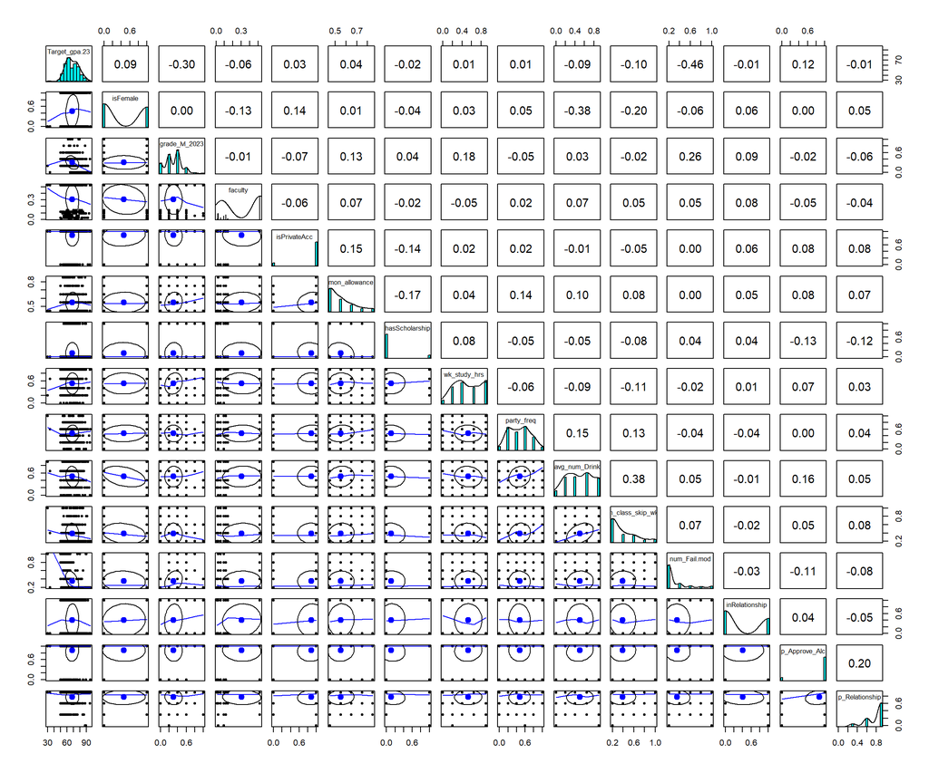

Granted *scaling* the data to have an altered range will not change the distribution or correlation of the dataset to another feature. But re-scaling will assist with regression model training an creation by balancing the impact of all features on the target variable and ensuring that feature scale is not the cause of a feature over-powering or drowning out a more relevant feature based on magnitude of numbers alone.

Contrasting to scales, is z-score normalization. Min-Max Normalization leveled the feature impact with preserving intra-feature magnitude importance, but z-score normalization centers the mean to 0 and sets the standard deviation to 1, pushing the features to a more normal distribution and making any variance differences apparent instead of potentially being convoluted by a difference in feature mean. z-Score standardization will be used when evaluating Principle Component Analysis after any obvious feature correlation is removed from the dataset, to reduce PCA computational redundancies and aid in multicollinearity and linear transformation reductions.

### 2. Pearson’s Correlation Matrix : Numeric Value

Pearson’s Correlation Coefficient for Features

|  | Target_gpa.23 | isFemale | grade_lvl_2023 | faculty | isPrivateAcc | mon_allowance | hasScholarship | wk_study_hrs | party_freq | avg_num_Drink | n_class_skip_wk | num_Fail.mod | inRelationship | p_Approve_Alc | p_Relationship |
| --- | --- | --- | --- | --- | --- | --- | --- | --- | --- | --- | --- | --- | --- | --- | --- |
| Target_gpa.23 | 1.0000000 | 0.0912063 | -0.2967841 | -0.0648435 | 0.0336190 | 0.0401171 | -0.0183287 | 0.0144180 | 0.0148926 | -0.0867062 | -0.1045351 | -0.4635634 | -0.0137107 | 0.1180388 | -0.0148259 |
| isFemale | 0.0912063 | 1.0000000 | 0.0048238 | -0.1293274 | 0.1368124 | 0.0096726 | -0.0366666 | 0.0312042 | 0.0504709 | -0.3778169 | -0.2014326 | -0.0616582 | 0.0596968 | -0.0041503 | 0.0540161 |
| grade_lvl_2023 | -0.2967841 | 0.0048238 | 1.0000000 | -0.0149358 | -0.0663404 | 0.1256893 | 0.0402658 | 0.1761884 | -0.0482772 | 0.0331655 | -0.0210262 | 0.2645800 | 0.0914445 | -0.0201755 | -0.0607950 |
| faculty | -0.0648435 | -0.1293274 | -0.0149358 | 1.0000000 | -0.0619329 | 0.0699041 | -0.0212499 | -0.0544618 | 0.0154288 | 0.0733459 | 0.0509045 | 0.0529216 | 0.0841762 | -0.0492556 | -0.0411757 |
| isPrivateAcc | 0.0336190 | 0.1368124 | -0.0663404 | -0.0619329 | 1.0000000 | 0.1534884 | -0.1364413 | 0.0199907 | 0.0170477 | -0.0108243 | -0.0475282 | 0.0010226 | 0.0630001 | 0.0770945 | 0.0777181 |
| mon_allowance | 0.0401171 | 0.0096726 | 0.1256893 | 0.0699041 | 0.1534884 | 1.0000000 | -0.1675881 | 0.0414959 | 0.1422524 | 0.0995948 | 0.0835204 | -0.0008000 | 0.0497841 | 0.0762225 | 0.0740500 |
| hasScholarship | -0.0183287 | -0.0366666 | 0.0402658 | -0.0212499 | -0.1364413 | -0.1675881 | 1.0000000 | 0.0786032 | -0.0523847 | -0.0460380 | -0.0789784 | 0.0419396 | 0.0385367 | -0.1285250 | -0.1184861 |
| wk_study_hrs | 0.0144180 | 0.0312042 | 0.1761884 | -0.0544618 | 0.0199907 | 0.0414959 | 0.0786032 | 1.0000000 | -0.0641344 | -0.0946167 | -0.1053835 | -0.0190640 | 0.0084977 | 0.0689105 | 0.0324041 |
| party_freq | 0.0148926 | 0.0504709 | -0.0482772 | 0.0154288 | 0.0170477 | 0.1422524 | -0.0523847 | -0.0641344 | 1.0000000 | 0.1486309 | 0.1331224 | -0.0403829 | -0.0355045 | -0.0031914 | 0.0375957 |
| avg_num_Drink | -0.0867062 | -0.3778169 | 0.0331655 | 0.0733459 | -0.0108243 | 0.0995948 | -0.0460380 | -0.0946167 | 0.1486309 | 1.0000000 | 0.3793827 | 0.0534964 | -0.0097489 | 0.1645273 | 0.0549303 |
| n_class_skip_wk | -0.1045351 | -0.2014326 | -0.0210262 | 0.0509045 | -0.0475282 | 0.0835204 | -0.0789784 | -0.1053835 | 0.1331224 | 0.3793827 | 1.0000000 | 0.0664168 | -0.0210169 | 0.0511961 | 0.0797365 |
| num_Fail.mod | -0.4635634 | -0.0616582 | 0.2645800 | 0.0529216 | 0.0010226 | -0.0008000 | 0.0419396 | -0.0190640 | -0.0403829 | 0.0534964 | 0.0664168 | 1.0000000 | -0.0297638 | -0.1136481 | -0.0773815 |
| inRelationship | -0.0137107 | 0.0596968 | 0.0914445 | 0.0841762 | 0.0630001 | 0.0497841 | 0.0385367 | 0.0084977 | -0.0355045 | -0.0097489 | -0.0210169 | -0.0297638 | 1.0000000 | 0.0433790 | -0.0462980 |
| p_Approve_Alc | 0.1180388 | -0.0041503 | -0.0201755 | -0.0492556 | 0.0770945 | 0.0762225 | -0.1285250 | 0.0689105 | -0.0031914 | 0.1645273 | 0.0511961 | -0.1136481 | 0.0433790 | 1.0000000 | 0.2027765 |
| p_Relationship | -0.0148259 | 0.0540161 | -0.0607950 | -0.0411757 | 0.0777181 | 0.0740500 | -0.1184861 | 0.0324041 | 0.0375957 | 0.0549303 | 0.0797365 | -0.0773815 | -0.0462980 | 0.2027765 | 1.0000000 |

Pearson’s Correlation Matrix is a standard coefficient to rank a feature’s relationship to another feature. Because all features are numeric with rank or direction Pearson’s is a good method to evaluate even though some features are technically categorical, they were given meaningful numeric levels.

The correlation between features is generally ranked as ‘None’ [0,0.2), ‘Weak’ p[0.2, 0.4), ‘Moderate’ [0.4, 0.7), ‘Strong’ [0.7, 1.0), and the theoretically ‘Perfect’ [1], which is only seen on the diagonal for a feature crossed with itself. In this correlation matrix the `Grade_Lvl_Last_Year` and `Failed_Module_Count` seem to have a ‘weak’ correlation, so I’ll keep that in mind for the next go around for imputation of feature missing values.

### 3. Pearson Correlation Matrix : Quick Reference

Remove Multicollinearity : 0.7 + Strong / Remove  
weak > 0.2  
moderate > 0.4 & < 0.7

Target_gpa.23

isFemale

grade_lvl_2023

faculty

isPrivateAcc

mon_allowance

hasScholarship

wk_study_hrs

party_freq

avg_num_Drink

n_class_skip_wk

num_Fail.mod

inRelationship

p_Approve_Alc

p_Relationship

Target_gpa.23

(self)

weak

moderate

isFemale

(self)

weak

weak

grade_lvl_2023

weak

(self)

weak

faculty

(self)

isPrivateAcc

(self)

mon_allowance

(self)

hasScholarship

(self)

wk_study_hrs

(self)

party_freq

(self)

avg_num_Drink

weak

(self)

weak

n_class_skip_wk

weak

weak

(self)

num_Fail.mod

moderate

weak

(self)

inRelationship

(self)

p_Approve_Alc

(self)

weak

p_Relationship

weak

(self)

Any highly correlated features should have at least one of the 2 or more features removed. The idea is to have as few features, and as few highly correlated features as possible to get a simple but effective model that is not over inflated by compounding relational effects on the target feature. While Pearson’s evaluated the linear association between two variables (ranges from -1 to +1), PCA with evaluate the difference in variance between two features and utilize linear transformations to reduce any remaining multicollinearity in the dataset.

There are a few weak linear correlations when evaluated using “Pearson” between feature levels such as the subjectively implied ranked parent relationship strength with the student. None-of these features have significant correlations that warrant removal to avoid multicollinearity effects with listing as “weak” and one at “moderate”. However, use of PCA will help to further reduce association through linear transformation to help assess feature selection for model training.

## 7. Priciple Component Analysis (PCA) [^7] :

Converts remaining correlated features into orthogonal components (perpendicular). This handles residual multicollinearity and helps reduces dimensions for a more stable regression model. Perform PCA to assist in feature selection analysis and determined an optimal “k” for feature selection in the linear model transformations. PCA can help with noise reduction. Performs PCA on predictors to create uncorrelated components. Fits a regression model using these components instead of original features.

- Handles remaining multicollinearity.
- Reduces dimensions
- Improves stability of regression coefficients.

*Important Notes:*

- Min–max normalization only sets the range to [0, 1]
- `center = TRUE` is still necessary because PCA assumes data is centered (`mean = 0`) so that the first component captures variance, not the mean offset.
- `scale. = TRUE` standardizes to unit variance (z-Score) with `sd` set to 1, allowing for variance to be analyzed. Features with higher variance (even within [0, 1]) will dominate PCA scaling if standardizing the data is skipped. This will give equal weight to all features, so should also be used for correlation matrix evaluation.
- Unsupervised Learning Technique : remove target from data before imputing for PCA. Keeping the target in it’s “original” units makes the interpretation easier.
- pca_result$rotation = transformation matrix of PCA linear transformation that form the Principle Component (PC)
  - PCA $rotation matrix columns = linear transformation’s weighted coefficients applied to the original feature
  - PCA $rotation matrix rows = original feature used ; so row index = predictor feature column index - 1 (due to target removal)

### 1. z-Score Standardization of the Data for PCA use

*note* : `scale` and `center` will be called directly inside functions to standardize the data for models that require it : PCA, Lasso, SVR  
Again, the z-Score standardizes the data to reflect a normal distribution with mean = 0 and standard deviation = 1. PCA evaluates variance differences and so normalizing the mean is very important for easy of interpretation and increased meaning due to PCA performing various ‘hidden’ linear transformations to remove multicollinearity, thereby making interpretation less intuitive depending.

### 2. PCA modeling : train, prune, evaluate

```r
# remove target and use center/scale to standardize for PCA
pca_result <- prcomp(df[,-1], center = TRUE, scale. = TRUE)

# target feature with corresponding principle component feature scores
# index to identify best k [,1:k] later
pc_scores <- data.frame(Target = df$Target_gpa.23,
                        pca_result$x)
```

Feature’s Transformed (display first 10 rows of df)

| Target | PC1 | PC2 | PC3 | PC4 | PC5 | PC6 | PC7 | PC8 | PC9 | PC10 | PC11 | PC12 | PC13 | PC14 |
| --- | --- | --- | --- | --- | --- | --- | --- | --- | --- | --- | --- | --- | --- | --- |
| 72 | 0.9576489 | -0.9465767 | -0.6217772 | 1.0026796 | 0.1244749 | 1.0377563 | 1.4833580 | -0.5116785 | 0.0182062 | -0.6354872 | -1.9324746 | 0.1721096 | -0.7307369 | 0.7685637 |
| 75 | 1.4323499 | 0.5148276 | -0.7585876 | 0.9479852 | 0.0432021 | 1.9953189 | -0.6793820 | 0.6734948 | 2.1098506 | -1.0155090 | 0.7031819 | 2.0900562 | -0.3342062 | -1.7350782 |
| 55 | 1.8975793 | -0.2386805 | 1.3440712 | 1.2377510 | -0.7823310 | -0.5637449 | 0.9508605 | 0.4088851 | -0.0648585 | -0.6121665 | -0.4279906 | 0.0450390 | -0.5778040 | -0.0670345 |
| 84 | 2.1553473 | -0.7797894 | -0.4602441 | -0.0000684 | 0.2184326 | 1.0074946 | 1.2575370 | 0.0775870 | -0.4708012 | -0.5349073 | 0.2912755 | -1.0482990 | -0.0672759 | -0.2179056 |
| 52 | -0.3294841 | 0.9306889 | -0.4813388 | -0.8505137 | -1.6752790 | -0.5315614 | 1.3195613 | 0.4523408 | -0.9674166 | 1.9629586 | -0.7702958 | 0.8393483 | -0.0059875 | 0.5761190 |
| 83 | 1.5264840 | -1.2584567 | -0.0745413 | -0.0431642 | -0.1155474 | 1.6191642 | 0.6500193 | 0.3943733 | 0.5650089 | -0.6309333 | -1.3277307 | -0.3226572 | 2.1950214 | -1.1507704 |
| 54 | 0.7857599 | -0.1974012 | -0.4066016 | 1.1404750 | 0.2770213 | -0.1746650 | -1.4181261 | 0.6649142 | 0.5216833 | 0.0631829 | -0.4318664 | -0.3008604 | -0.7573223 | -0.1439249 |
| 75 | 0.1867902 | -1.4615154 | -0.2763788 | -0.5335510 | -0.0730122 | 1.0488872 | 1.3107021 | -1.0945029 | -0.3592344 | -0.3392593 | -0.4901931 | -0.1174515 | -0.3301228 | -0.5836878 |
| 89 | -0.2039752 | -1.2288717 | 0.9453198 | 1.1330781 | -0.5207515 | 0.3407373 | -0.7084713 | 1.2512947 | 0.3686019 | 0.1203910 | -0.2550574 | -0.8793959 | 1.0875970 | -0.2611529 |
| 83 | 2.3059000 | -0.5784441 | 1.4097212 | -0.3748125 | -1.1005485 | 0.8292921 | 0.8140710 | 1.3724913 | -0.6100607 | -0.4589700 | -0.4486346 | 1.0838320 | 0.7701404 | -0.9329589 |

Principle Component Analysis uses the predictor feature’s variance structure, not their correlation with the `Target_gpa.23` when performing linear transformations. Default setting `retx = TRUE` returns the rotated variables in $x. So the above matrix shows all of the scores for each Principal Component’s feature impact with the current linear transformation for model performance.

While my signature project ensemble is not slotted to use PCA in it’s prediction, I will do a training on the normalized full data set and have `step()` evaluate AIC by backwards elimination to check if the Principle Component feature ideal to select a starting feature combination as my base formula for each model training even without the linear transformation applied.

$$\text{Original Data Value} =
(\text{X}_{scaled} \times \text{scale}) + \text{center}$$

Weight Coefficient and Shift applied to Data Values

|  | Scale | Center |
| --- | --- | --- |
| isFemale | 0.499 | 0.464 |
| grade_lvl_2023 | 0.204 | 0.303 |
| faculty | 0.229 | 0.306 |
| isPrivateAcc | 0.322 | 0.883 |
| mon_allowance | 0.122 | 0.553 |
| hasScholarship | 0.319 | 0.115 |
| wk_study_hrs | 0.288 | 0.531 |
| party_freq | 0.251 | 0.471 |
| avg_num_Drink | 0.281 | 0.505 |
| n_class_skip_wk | 0.248 | 0.389 |
| num_Fail.mod | 0.246 | 0.350 |
| inRelationship | 0.491 | 0.404 |
| p_Approve_Alc | 0.328 | 0.878 |
| p_Relationship | 0.201 | 0.771 |

### 3. `lm()` Stepwise Feature Seletion on regular regression

```r
# method 1 : feature selection
feat_model <- lm(Target_gpa.23 ~ ., data = df)
feature_select <- step(feat_model, trace =0)
summary(feature_select)
```

```
##
## Call:
## lm(formula = Target_gpa.23 ~ grade_lvl_2023 + mon_allowance +
##     n_class_skip_wk + num_Fail.mod + p_Approve_Alc + p_Relationship,
##     data = df)
##
## Residuals:
##     Min      1Q  Median      3Q     Max
## -38.811  -6.273  -0.278   5.316  35.596
##
## Coefficients:
##                 Estimate Std. Error t value Pr(>|t|)
## (Intercept)       75.580      2.765  27.338  < 2e-16 ***
## grade_lvl_2023   -10.008      2.209  -4.530 7.83e-06 ***
## mon_allowance      5.883      3.585   1.641   0.1016
## n_class_skip_wk   -3.501      1.759  -1.990   0.0473 *
## num_Fail.mod     -16.254      1.836  -8.853  < 2e-16 ***
## p_Approve_Alc      2.509      1.352   1.856   0.0643 .
## p_Relationship    -3.640      2.200  -1.655   0.0988 .
## ---
## Signif. codes:  0 '***' 0.001 '**' 0.01 '*' 0.05 '.' 0.1 ' ' 1
##
## Residual standard error: 8.616 on 394 degrees of freedom
## Multiple R-squared:  0.2689, Adjusted R-squared:  0.2577
## F-statistic: 24.15 on 6 and 394 DF,  p-value: < 2.2e-16
```

### 4. Evaluation of PCA and Linearity with Ranked feature impact

```r
# method 2 : caret ; with cross-validation
pca_ctrl <- trainControl(method = "cv",
                         # repeat 5 times
                         number = 5)

pca_model <- train(Target_gpa.23 ~ .,
                   # use df b/c preProcess
                   data = df,
                   method = "lmStepAIC", # caret step() version
                   trace = FALSE, # no print out
                   preProcess = c("center", "scale", "pca"),
                   trControl = pca_ctrl)

# PCnum is one less than feat col
features <- colnames(df[,c(2,3,4,6,9,10)])
formula_use <- paste0("Target_gpa.23 ~ ",paste0(features, collapse = " + "))

summary(pca_model)
```

```
##
## Call:
## lm(formula = .outcome ~ PC1 + PC2 + PC3 + PC5 + PC6 + PC7 + PC8 +
##     PC9 + PC12, data = dat)
##
## Residuals:
##     Min      1Q  Median      3Q     Max
## -38.517  -6.154  -0.248   5.306  34.053
##
## Coefficients:
##             Estimate Std. Error t value Pr(>|t|)
## (Intercept)  68.1497     0.4321 157.734  < 2e-16 ***
## PC1          -0.7074     0.3200  -2.211 0.027648 *
## PC2          -2.2127     0.3445  -6.424 3.86e-10 ***
## PC3           2.4313     0.3707   6.559 1.72e-10 ***
## PC5           1.6190     0.4148   3.903 0.000112 ***
## PC6           1.5851     0.4323   3.666 0.000280 ***
## PC7          -0.6306     0.4444  -1.419 0.156685
## PC8           1.7547     0.4574   3.836 0.000146 ***
## PC9          -1.1670     0.4705  -2.480 0.013551 *
## PC12          0.8702     0.5250   1.658 0.098198 .
## ---
## Signif. codes:  0 '***' 0.001 '**' 0.01 '*' 0.05 '.' 0.1 ' ' 1
##
## Residual standard error: 8.652 on 391 degrees of freedom
## Multiple R-squared:  0.2684, Adjusted R-squared:  0.2516
## F-statistic: 15.94 on 9 and 391 DF,  p-value: < 2.2e-16
```

The PCA final Model selected based on the AIC score evaluation is listed above.

### 6. PCA ‘elbow’ :

The PCA ‘elbow’ refers to the point on a scree plot (variance explained vs. number of principal components) where the curve changes from steep to flat—like an “elbow” in the graph, the elbow is the point where the curve bends sharply and then flatten. The scree plot shows variance explained by each principal component. The first few components explain most of the variance (steep slope). After a certain point, adding more components explains very little extra variance (flat slope). The elbow point is where this transition happens—beyond it, components mostly capture noise.

- The “elbow” is the point at which the curve sharply bends and switches from a steep slope to a flattened line
- indicates optimal k for linear regression model (i.e. 4 here, could potentially argue for 6 because there is still a significant decrease from 5 to 6). This PCA number of components should balances dimensional reduction while also retaining most of the model variance.
- Before elbow = informative components.
- After elbow = diminishing returns.
- Uses variance structure of predictors, not their correlation with the Target_gpa.23 when selecting components.

### 7. PCA Scree Plot for Number of Features to Select without Overfitting

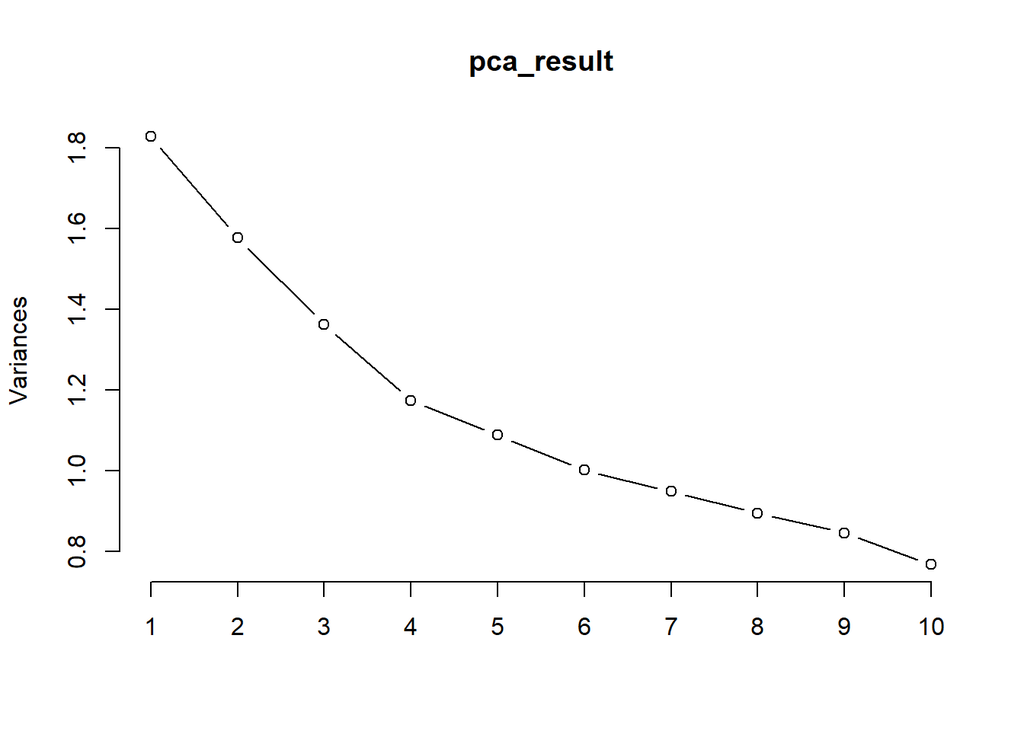

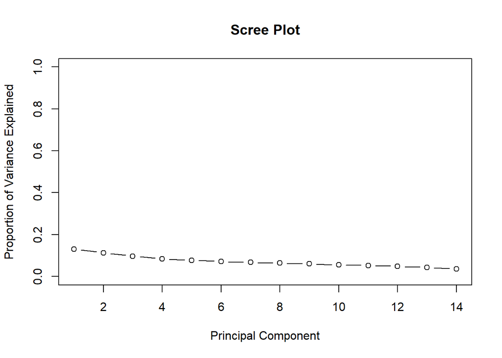

### 9. Select top 6 features based on ‘elbow’ estimate

Rank the features to find original features that have the biggest impact for PC1 to PC6.

```r
loadings <- pca_result$rotation
loadings
```

```
##                          PC1         PC2         PC3          PC4           PC5
## isFemale        -0.389112577 -0.35292147 -0.08656921 -0.232415485 -1.437010e-01
## grade_lvl_2023  -0.022751540  0.21048483 -0.64412611  0.100287791 -1.370037e-01
## faculty          0.162054725  0.17906547 -0.04136652 -0.315490046  4.898897e-01
## isPrivateAcc    -0.005554936 -0.40080587 -0.18475018 -0.212344304  4.344209e-05
## mon_allowance    0.226069806 -0.25933798 -0.40743429 -0.263014710  4.972793e-03
## hasScholarship  -0.196021281  0.36874114  0.05332305  0.203242699  8.580176e-02
## wk_study_hrs    -0.163974886 -0.04809072 -0.37455951  0.456262943  1.759115e-02
## party_freq       0.233868662 -0.14379602  0.04198038 -0.348979406 -2.657288e-01
## avg_num_Drink    0.574422908  0.11576714 -0.01590819  0.140658579  2.865109e-02
## n_class_skip_wk  0.501560533  0.08176239  0.04123455  0.001451592 -1.130428e-01
## num_Fail.mod     0.050903859  0.33311695 -0.39245183 -0.138485281 -3.430932e-01
## inRelationship  -0.041088355 -0.02827726 -0.26252839 -0.145815439  6.764219e-01
## p_Approve_Alc    0.202900042 -0.35906667 -0.07635660  0.448087325  2.100992e-01
## p_Relationship   0.153929973 -0.38914527  0.01170497  0.299741537 -9.632978e-02
##                         PC6         PC7         PC8          PC9          PC10
## isFemale         0.13180681  0.12163697 -0.35891266  0.005470349  0.0602297714
## grade_lvl_2023   0.04977071  0.01229969 -0.19388165 -0.234207695 -0.0004334005
## faculty         -0.09008918 -0.56098878 -0.16357594  0.333695155  0.2370005723
## isPrivateAcc    -0.28514518  0.31884605  0.50236794  0.447617988  0.0899179256
## mon_allowance    0.15850699 -0.25709931  0.21937405 -0.106012699 -0.2769591705
## hasScholarship   0.41472516  0.26521275  0.04471408  0.515552638  0.0330976939
## wk_study_hrs     0.29968726 -0.30450815  0.30744563  0.170354016 -0.0630276804
## party_freq       0.66256515  0.01629675 -0.08721917  0.073796787  0.3545096392
## avg_num_Drink    0.04694865  0.19231939  0.14436118  0.011865196  0.0992052357
## n_class_skip_wk  0.05178193  0.20058905 -0.12077882  0.040296433 -0.3808661809
## num_Fail.mod    -0.36514741  0.13799885 -0.21240285  0.260508508  0.2640758693
## inRelationship   0.13059541  0.46405759 -0.21235878 -0.070593831 -0.1868508663
## p_Approve_Alc   -0.05857042  0.09288002 -0.13141490 -0.168917316  0.6049951146
## p_Relationship  -0.07807520 -0.13787947 -0.50921300  0.467714681 -0.3147969881
##                        PC11        PC12        PC13          PC14
## isFemale        -0.13783800  0.44575635 -0.19371142  0.4711794658
## grade_lvl_2023   0.09976106 -0.13686696 -0.58423486 -0.2153259894
## faculty         -0.11184545  0.15157734 -0.21874168 -0.0006548636
## isPrivateAcc    -0.07922995 -0.04894605 -0.27949329 -0.1718145664
## mon_allowance    0.52340327  0.24022375  0.28960738  0.0600554110
## hasScholarship   0.43092527  0.26675535 -0.05180617 -0.0577041370
## wk_study_hrs    -0.50973708  0.01952498  0.18428261  0.1333893181
## party_freq      -0.14304205 -0.30173910  0.06766805 -0.1907682522
## avg_num_Drink    0.03685456 -0.12301967 -0.21650799  0.7087990925
## n_class_skip_wk -0.38174246  0.53327735 -0.05555110 -0.2998086002
## num_Fail.mod    -0.06286159  0.01782153  0.49905298  0.0843638860
## inRelationship  -0.14586259 -0.22929710  0.24167147  0.0112482445
## p_Approve_Alc    0.13086610  0.29013879  0.11183049 -0.2036091857
## p_Relationship   0.15126851 -0.31671733 -0.01261233 -0.0006783279
```

```r
contribution_rank <- rowSums(abs(loadings))
feature_rank <- sort(contribution_rank, decreasing = TRUE)
feat_rank_tbl <- kbl(feature_rank, digit = 3, caption = "Original Feature Weighted importance for Principle Component") %>%
  kable_styling(full_width = FALSE)
print(feature_rank)
```

```
##   mon_allowance    num_Fail.mod        isFemale   p_Approve_Alc         faculty
##        3.292072        3.162285        3.131262        3.089732        3.056035
##    wk_study_hrs    isPrivateAcc  hasScholarship  p_Relationship      party_freq
##        3.052436        3.026878        2.987623        2.939807        2.931958
##  inRelationship n_class_skip_wk  grade_lvl_2023   avg_num_Drink
##        2.846667        2.803744        2.641436        2.455289
```

Original Feature Weighted importance for Principle Component

|  | x |
| --- | --- |
| mon_allowance | 3.292 |
| num_Fail.mod | 3.162 |
| isFemale | 3.131 |
| p_Approve_Alc | 3.090 |
| faculty | 3.056 |
| wk_study_hrs | 3.052 |
| isPrivateAcc | 3.027 |
| hasScholarship | 2.988 |
| p_Relationship | 2.940 |
| party_freq | 2.932 |
| inRelationship | 2.847 |
| n_class_skip_wk | 2.804 |
| grade_lvl_2023 | 2.641 |
| avg_num_Drink | 2.455 |

# 4. Modeling Process :

## 1. Split Data : Training and Testing

### 1. Holdout Test Set : single split with preserved proportions `caret::createDataPartition()`

```r
#set.seed reproduce
set.seed(555)

# 1. split data
train_idx <- createDataPartition(df$Target_gpa.23, p = 0.8, list = FALSE)

#svr and glm
df.train <- df[train_idx, ]
df.test  <- df[-train_idx, ]
# rf
rF.train <- df.fac[train_idx,]
rF.test <- df.fac[-train_idx,]
```

### 2. Bagging Globally : to have consistent bagged data used for all 3 homogenous ensembles

```r
# 25 bagged random samples
nbags <- 25

bootstrp_bags_idx <- lapply(1:nbags, function(x){
  sample(1:nrow(df.train), nrow(df.train), replace = TRUE)
})
```

Create 25 globally accessing bags that utilize Bootstrap Sampling specifically to sample the training data with replacement and create identical length samples for model training, and subsequently the model evaluation allowing for lineup of predictions across models.

`df.train` is the designated pool of observations for model training, but will sample with replacement for the same length data.frame to training various models based on the same starting formula/framework. Utilize step() to refine model based on designated subset for training. Then combine homogoneous ensemble to average prediction for final combined output, Evaluate model performance.

## 2. Tuning Parameters

### 3. Define Grids Globally : Allow the testing of multiple Hyper-parameters dependent on Model Used

[The `grid` element](https://topepo.github.io/caret/using-your-own-model-in-train.html#introduction-1) Use `expand.grid` to tune hyper parameters specific to the model being trained instead of all in the `trcontrol` that way the `trControl` can be broadly applied to each model.

```r
# re-subsample of the already bootstrapped bag 20 times
# allowing for hyperparameter tuning
cv_ctrl <- trainControl(method = "cv",
                        number = 20,
                        savePredictions = "final")

# Lasso Grid
lasso_grid <- expand.grid(
  # lasso is purely alpha = 1
  alpha = 1,
  # test 20 lambda
  lambda = seq(0.0001, 10, length = 20)
)

# SVR Grid
sigmas <- kernlab::sigest(as.matrix(df.train[,-1]), na.action = na.omit, scaled = TRUE)
# Tune cost (C), epsilon, and gamma for RBF kernel where sigma = 1/(2*gamma^2)
# caret's 'svmRadial' is RBF kernel & expects sigma not gamma
svr_grid <- expand.grid(
  # 3 sigma values
  sigma = sigmas,
  # cost 0 = most strict regularizing, high # not strict
  # test 10 costs
  C = 2 ^(1:10)
)

# Random Forest Grid
# number of predictor features used
rF_grid <- expand.grid(
  # define number of random splits of features to try
  mtry = c(1,2,4,7)
)
```

Lasso : the Elastic Net Family for liner regression models

- alpha controls the penalty result :
  - **Lasso = 1 where feature selection is encouraged by reducing coefficients to 0**
  - Ridge = 0 does not fully remove features by having shrinkage approach 0 but not be zero (mostly)
  - alpha = between 0 and 1 is a mix of the two penalties that are on a continuous scale
- lambda is a ‘regularization’ strength:
  - Small lambda = weaker penalty for errors with coefficients closer to regular Ordinal Least Squares.
  - Large lambda = stronger penalty for errors leading to more shrinkage bringing the resultant coefficients closer to zero.

SVR:

- `kernlab::sigest` is a function that provides “Hyperparameter estimation for the Gaussian Radial Basis kernel” as titled by RHelp Documentation, it returns the lower, median, and upper estimates

Random Forest: mtry controls how many features are considered at each split:

- Smaller mtry = more randomness, potentially lower correlation among trees and increased generalization.
- Larger mtry = trees can choose splits from more predictor features, which often lower bias but can increase variance.

## 3. Train Models

### 1. Numeric Dataset Required : Lasso and SVR

```r
# initialize model list for storage of each ensemble model on the bootstrab bags
lasso_models <- vector('list')
svr_models <- vector('list')
rF_models <- vector('list')

# 4. train models using same train control i.e. same bags
for(i in 1:length(bootstrp_bags_idx)){

  sample <- bootstrp_bags_idx[[i]]
  sample_x <- df.train[sample,]

  # Lasso
  lasso_models[[i]] <- train(
    Target_gpa.23 ~ grade_lvl_2023 + mon_allowance + n_class_skip_wk + num_Fail.mod + p_Approve_Alc + p_Relationship + avg_num_Drink,
    data = sample_x,
    method = "glmnet",
    tuneGrid = lasso_grid,
    trControl = cv_ctrl,
    metric = "RMSE",
    preProcess = c("center", "scale"),
    na.action = na.omit)

  # support vector machine for regression model
  svr_models[[i]] <- train(
    Target_gpa.23 ~ grade_lvl_2023 + mon_allowance + n_class_skip_wk + num_Fail.mod + p_Approve_Alc + p_Relationship + avg_num_Drink,
    data = sample_x,
    method = "svmRadial",
    tuneGrid = svr_grid,
    trControl = cv_ctrl,
    metric = "RMSE",
    preProcess = c("center", "scale"),
    na.action = na.omit)
}
```

### 2. Factored Dataset Preferred : Random Forest Regression

```r
for(i in 1:length(bootstrp_bags_idx)){

  sample <- bootstrp_bags_idx[[i]]
  sample_x <- rF.train[sample,]

  # random forest regression model
  rF_models[[i]] <- train(
    Target_gpa.23 ~ grade_lvl_2023 + mon_allowance + n_class_skip_wk + num_Fail.mod + p_Approve_Alc + p_Relationship + avg_num_Drink,
    data = sample_x,
    method = "rf",
    tuneGrid = rF_grid,
    trControl = cv_ctrl,
    ntree = 1000,
    importance = TRUE,
    metric = "RMSE",
    na.ation = na.omit)
}
```

Lasso : glmnet : the Elastic Net Family for liner regression models

- scaling and centering highly encouraged
- `NA` values must be process either in the model or ahead of time, while I did resolve all `NA` prior I did receive errors and therefore as a guard initialized `na.action = na.omit`
- interested in the “RMSE” metrics for model comparison across the 3 types and even within

SVR:

- scaling and centering highly encouraged
- `NA` values must be process either in the model or ahead of time, while I did resolve all `NA` prior I did receive errors and therefore as a guard initialized `na.action = na.omit`
- interested in the “RMSE” metrics for model comparison across the 3 types and even within

Random Forest:

- scaling and centering is not needed for random forest
- `NA` values don’t necessarily need an action but for consistence `na.action = na.omit`
- interested in the “RMSE” metrics for model comparison across the 3 types and even within
- increase number of trees used from base 500 to 1000

## 4. Homogenous Ensemble Function

```r
homogenous_ensemble_model <- function(list_models, test_data){
  nbags <- length(list_models)
  # initialize matrix for model predictions/avg
  bag_preds <- matrix(NA, nrow = nrow(df.test), ncol = nbags)

  for(i in 1:nbags){
    x_model <- list_models[[i]]
    model_prediction <- predict(x_model, newdata = test_data)
    bag_preds[,i] <- model_prediction
  }
  # average all predictions
  ensemble_pred <- rowMeans(bag_preds)
  return(ensemble_pred)
}
```

### 2. Decision Regression Forest Ensemble

- Very good for non-normal data categorization, considered less effective for regression due to the continuous nature of the target but it is still a fairly useful method
- this is already technically an ensemble by design, but I did run it through the sampled bags like SVR and Lasso for consistency
- Ordinal features (stored as numeric in [0,1]) are fine for Random Forests. If a variable is truly categorical (like Sex, Faculty), convert to factor. (initially was going to use “Ranger” from caret for the method but it required extra package dependencies so I opted for the “rf” that I knew would knit without installing other packages not covered in the course).
- Tuning mtry: Good starting values are sqrt(number of predictor features) or a fraction of them at 10–30%. Given the lower formula by PCA just incrementally iterated the range possible..
- min.node.size: Larger values simplify trees and can improve generalization on small datasets.
- num.trees: 500–2000 is typical; more trees stabilize predictions but increase training time.

### 3. Support Vector Machines / Regression Ensemble

SVM (Support Vector Machine) is a supervised machine learning algorithm used for classification, regression, and sometimes outlier detection. SVM finds the optimal hyperplane that separates data points of different classes in a *feature space*. It’s goal is to maximize the margin (distance) between the hyperplane and the nearest data points from each class (called support vectors). They provide a very compact way to store classification models. Overall SVM is considered a Penalization Method, much lke Lasso and Ridge Regression Models. [^8]

#### What is SVR Used For :

- Text classification (spam detection)
- Image recognition
- Classification
- **(my task)** Regression tasks (aka Support Vector Regression, SVR)
- capable of learning complex patterns without sensitivity to noise in the data

# 5. Evaluation of Models : Individually and Together

### 1. Use Homogeneous Ensemble for Predictions

```r
lasso_pred <- homogenous_ensemble_model(lasso_models, df.test)
svr_pred <- homogenous_ensemble_model(svr_models, df.test)
rF_pred <- homogenous_ensemble_model(rF_models, rF.test)
```

### 2. Homogeneous Model Preditions Data.Frame

Data Frame of All Homogeneous Model Predictions

| Answer | Lasso_Model | SVR_Model | Random_Forest |
| --- | --- | --- | --- |
| 72 | 68.1 | 65.8 | 67.1 |
| 75 | 73.8 | 73.6 | 75.3 |
| 76 | 71.3 | 72.0 | 74.5 |
| 86 | 75.2 | 77.9 | 79.2 |
| 54 | 69.7 | 72.6 | 62.7 |
| 69 | 69.4 | 71.6 | 70.4 |
| 84 | 74.3 | 74.2 | 78.2 |
| 90 | 53.9 | 54.8 | 56.9 |
| 83 | 74.9 | 78.0 | 79.4 |
| 70 | 75.7 | 77.8 | 79.1 |

### 3. Evaluate Homogenous Ensemble Model Performance Individually

#### 1. Function To Calculate Model Metrics

```r
calc_errors <- function(answer_vec, pred_vec){
  m_err <- answer_vec - pred_vec
  m_mse <- mean(m_err^2)
  m_rmse <- sqrt(m_mse)
  m_mae <- mean(abs(m_err))
  m_mape <- mean(abs(m_err / answer_vec)) * 100
  ssres <- sum(m_err^2)
  ssact <- sum((answer_vec - mean(answer_vec))^2)
  m_R2 <- 1 - (ssres/ssact)

  error_vec <- c("Mean Squared Error" = m_mse,
                 "Root Mean Squared Error" = m_rmse,
                 "Mean Absolute Error" = m_mae,
                 "Mean Absolute Percentage Error" = m_mape,
                 "R-Squared Error" = m_R2)

  return(error_vec)
}
```

```r
# performance
lasso_result <- calc_errors(df.ensemble$Answer, df.ensemble$Lasso_Model)
svr_result <- calc_errors(df.ensemble$Answer, df.ensemble$SVR_Model)
rF_result <- calc_errors(df.ensemble$Answer, df.ensemble$Random_Forest)
```

#### 2. Calulate Homogeneous Ensemble’s Weight for Heterogeneous Model using R-squared value

```r
# Weighted ensemble
R_sq <- c(lasso_result["R-Squared Error"],  svr_result["R-Squared Error"],  rF_result["R-Squared Error"])
model_wts <- R_sq/(sum(R_sq))
names(model_wts) <- c("Lasso_wt","SVR_wt","Random_Forest_wt")
print(model_wts)
```

```
##         Lasso_wt           SVR_wt Random_Forest_wt
##        0.2677799        0.1664883        0.5657318
```

#### 3. Model Performance

Model Performance Metrics and Designated Wt by R-Squared Value

|  | Lasso_Model | SVR_Model | Random_Forest |
| --- | --- | --- | --- |
| model weight | 0.268 | 0.166 | 0.566 |
| Mean Squared Error | 87.708 | 91.762 | 75.784 |
| Root Mean Squared Error | 9.365 | 9.579 | 8.705 |
| Mean Absolute Error | 7.372 | 7.551 | 6.554 |
| Mean Absolute Percentage Error | 10.951 | 11.313 | 9.830 |
| R-Squared Error | 0.109 | 0.068 | 0.230 |

### 4. Heterogeneous Ensemble

#### 1. Function

```r
heterogeneous_prediction <- function(num_data, factor_data, lasso_mod, svr_mod, rf_mod, mod_wts){
  lp <- homogenous_ensemble_model(lasso_mod, num_data)
  sp <- homogenous_ensemble_model(svr_mod, num_data)
  rp <- homogenous_ensemble_model(rf_mod, factor_data)
  final_prediction <- (mod_wts[1]*lp) + (mod_wts[2]*sp) + (mod_wts[3]*rp)
  return(final_prediction)
}
```

#### 2. Predictions

```r
#it's a long one to be a function
final_prediction <- heterogeneous_prediction(df.test, rF.test,lasso_models, svr_models, rF_models, model_wts)
df.ensemble$Weighted_Prediction <- final_prediction
final_display <- kbl(head(df.ensemble, 20), digit = 1, caption = "Ensemble Weighted Prediction of Avg 2023 GPA for Student<br>
                     only first 20 observation predictions printed") %>%
  kable_styling(full_width = FALSE)
```

Ensemble Weighted Prediction of Avg 2023 GPA for Student only first 20 observation predictions printed

| Answer | Lasso_Model | SVR_Model | Random_Forest | Weighted_Prediction |
| --- | --- | --- | --- | --- |
| 72.0 | 68.1 | 65.8 | 67.1 | 67.2 |
| 75.0 | 73.8 | 73.6 | 75.3 | 74.6 |
| 76.0 | 71.3 | 72.0 | 74.5 | 73.2 |
| 86.0 | 75.2 | 77.9 | 79.2 | 77.9 |
| 54.0 | 69.7 | 72.6 | 62.7 | 66.2 |
| 69.0 | 69.4 | 71.6 | 70.4 | 70.3 |
| 84.0 | 74.3 | 74.2 | 78.2 | 76.5 |
| 90.0 | 53.9 | 54.8 | 56.9 | 55.8 |
| 83.0 | 74.9 | 78.0 | 79.4 | 78.0 |
| 70.0 | 75.7 | 77.8 | 79.1 | 77.9 |
| 60.5 | 69.1 | 71.9 | 71.7 | 71.0 |
| 74.0 | 73.0 | 74.3 | 71.2 | 72.2 |
| 65.0 | 72.3 | 72.5 | 70.6 | 71.4 |
| 65.0 | 70.6 | 69.7 | 67.6 | 68.8 |
| 95.2 | 71.9 | 72.6 | 68.6 | 70.1 |
| 60.0 | 68.9 | 67.9 | 65.0 | 66.5 |
| 58.0 | 68.5 | 68.1 | 75.0 | 72.1 |
| 62.0 | 67.3 | 65.4 | 64.6 | 65.5 |
| 60.0 | 69.5 | 70.5 | 67.8 | 68.7 |
| 84.0 | 73.8 | 73.6 | 75.3 | 74.6 |

#### 3. Evaluate Heterogeneous Ensemble Performance Metrics

Model Performance Metrics and Designated Wt by R-Squared Value

|  | Lasso_Model | SVR_Model | Random_Forest | Ensemble_Model |
| --- | --- | --- | --- | --- |
| model weight | 0.268 | 0.166 | 0.566 | 1.000 |
| Mean Squared Error | 87.708 | 91.762 | 75.784 | 77.902 |
| Root Mean Squared Error | 9.365 | 9.579 | 8.705 | 8.826 |
| Mean Absolute Error | 7.372 | 7.551 | 6.554 | 6.707 |
| Mean Absolute Percentage Error | 10.951 | 11.313 | 9.830 | 10.029 |
| R-Squared Error | 0.109 | 0.068 | 0.230 | 0.209 |

## Model Performance Summary

### 1. Regression Model Evaluation Metrics & Meaning:

**Typially provide predictions with :**

- Confidence Interval
- Prediction Interval

However, due to the non-normal distribution the evaluation of these metrics would likely be off, and given the nexsted nature for retrieval and calculation of the interval, I will use RMSE as an estimate for the Prediction Interval though a 95% qualifying value is definitely not represented by RMSE. I decided to only calculate and evaluate the weighted prediction against the test data. Again the same test data held out from model training was used to test the homogeneous and heterogeneous ensembles.

### Performance Interpretation:

Model Performance Metrics and Designated Wt by R-Squared Value

|  | Lasso_Model | SVR_Model | Random_Forest | Ensemble_Model |
| --- | --- | --- | --- | --- |
| model weight | 0.268 | 0.166 | 0.566 | 1.000 |
| Mean Squared Error | 87.708 | 91.762 | 75.784 | 77.902 |
| Root Mean Squared Error | 9.365 | 9.579 | 8.705 | 8.826 |
| Mean Absolute Error | 7.372 | 7.551 | 6.554 | 6.707 |
| Mean Absolute Percentage Error | 10.951 | 11.313 | 9.830 | 10.029 |
| R-Squared Error | 0.109 | 0.068 | 0.230 | 0.209 |

- df,train : 322, 15
- df.test : 79, 15

The ensemble’s overall performance on the dataset is very low, while the heterogeneous resulted in a reduction of errors compared to the Lasso and SVR models, it performed worse than Random Forest. Random Forest has the highest weighted model influence on the ensemble prediction due to it’s overall better performance.

Original Feature Weighted importance for Principle Component

|  | x |
| --- | --- |
| mon_allowance | 3.292 |
| num_Fail.mod | 3.162 |
| isFemale | 3.131 |
| p_Approve_Alc | 3.090 |
| faculty | 3.056 |
| wk_study_hrs | 3.052 |
| isPrivateAcc | 3.027 |
| hasScholarship | 2.988 |
| p_Relationship | 2.940 |
| party_freq | 2.932 |
| inRelationship | 2.847 |
| n_class_skip_wk | 2.804 |
| grade_lvl_2023 | 2.641 |
| avg_num_Drink | 2.455 |

## References:

### Lasso/glmnet

1. [3.442 Ridge and Lasso Regression Code Reference](http://artificium.us/lessons/03.ml/l-3-442-ridge-lasso-regression/l-3-442.html)
2. [gaussian family glm](https://glmnet.stanford.edu/articles/glmnetFamily.html)
3. [R Package ‘caret’](https://cran.r-project.org/web/packages/caret/caret.pdf)
4. [bagControl() Framework](https://cran.r-project.org/web/packages/caret/caret.pdf)
5. [7.0.22 Linear Regression](https://topepo.github.io/caret/train-models-by-tag.html#linear-regression)

### SVR

RHelp Example in package `e1071`with `svm()`

```
## S3 method for class 'formula'
svm(formula, data = NULL, ..., subset, na.action =
na.omit, scale = TRUE)
## Default S3 method:
svm(x, y = NULL, scale = TRUE, type = NULL, kernel =
"radial", degree = 3, gamma = if (is.vector(x)) 1 else 1 / ncol(x),
coef0 = 0, cost = 1, nu = 0.5,
class.weights = NULL, cachesize = 40, tolerance = 0.001, epsilon = 0.1,
shrinking = TRUE, cross = 0, probability = FALSE, fitted = TRUE,
..., subset, na.action = na.omit)
```

- [13.2 Illustrative Examples : SVMs](https://topepo.github.io/caret/using-your-own-model-in-train.html#illustrative-example-1-svms-with-laplacian-kernels)
- $\text{SVM}^{struct}$ [Complex Outputs](https://www.cs.cornell.edu/people/tj/svm_light/svm_struct.html)
- [kernlab](https://www.jstatsoft.org/article/view/v011i09)
- [caret parameters and training SVR](https://topepo.github.io/caret/using-your-own-model-in-train.html#illustrative-example-1-svms-with-laplacian-kernels)

- important excerpt from caret documentation * : Why did we use kernlab::sigest instead of sigest? As previously mentioned, caret will not execute library(kernlab) unless you explicitly code it in these functions. Since it is not explicitly loaded, you have to call it using the namespace operator `::` [^10]
[^1]: 12.3.2 The SVM as a Penalization Method
[^2]: I googled how to make a [“vector arrow notation”](https://www.bing.com/search?q=latex%20vector%20arrow%20notation%20&qs=n&form=QBRE&sp=-1&lq=0&pq=latex%20vector%20arrow%20notation%20&sc=12-28&sk=&cvid=F4CF06B7C8BF44C69C242AAF5F75CADF) it came up in ‘Copilot Search’ without needing to click a link. should have known the logic behind a lot of notation is the same, so sometimes I get excited if I guess it correctly.
[^3]: [explicitly code kernlab in caret] (https://topepo.github.io/caret/using-your-own-model-in-train.html#introduction-1)
[^4]: 12.3.2 The SVM as a Penalization Method
[^5]: Downloading and Extracting a .csv file is new to me : Utilized Copilot prompt : ‘for mode = “wb”, can I dynamically code it to detect the user’s system’ & ‘Can Windows not use “w”?’ plus links to RCran Documentation for [download.file()](https://www.rdocumentation.org/packages/utils/versions/3.6.2/topics/download.file_)
[^6]: [explicitly code kernlab in caret] (https://topepo.github.io/caret/using-your-own-model-in-train.html#introduction-1)
[^7]: [what PCA is and how to index it](https://www.geeksforgeeks.org/r-language/principal-component-analysis-with-r-programming/)
[^8]: 12.3.2 The SVM as a Penalization Method
[^9]: I googled how to make a [“vector arrow notation”](https://www.bing.com/search?q=latex%20vector%20arrow%20notation%20&qs=n&form=QBRE&sp=-1&lq=0&pq=latex%20vector%20arrow%20notation%20&sc=12-28&sk=&cvid=F4CF06B7C8BF44C69C242AAF5F75CADF) it came up in ‘Copilot Search’ without needing to click a link. should have known the logic behind a lot of notation is the same, so sometimes I get excited if I guess it correctly.
[^10]: [explicitly code kernlab in caret] (https://topepo.github.io/caret/using-your-own-model-in-train.html#introduction-1)